# Introduction aux rapports reproductibles avec Quarto

Author

Raphaël Royauté

Published

December 21, 2023

### Rapports reproductibles

Un rapport reproductible vous permet de combiner du format texte avec votre code et leurs sorties (images, animations, tableau). C’est un format très pratique pour mettre au propre vos résultats et accompagner l’utilisateur sur les différentes étapes de mise en place de vos modèle. Ici j’utilise le système [Quarto](https://quarto.org/) qui est fourni directement à l’installation de RStudio. Vous trouverez plus d’informations sur les fonctions de base de Quarto avec RStudio dans ce [tutoriel](https://quarto.org/docs/get-started/hello/rstudio.html).

Dans les sections suivantes je reprends les scripts `sims_freefallin.R` et `sims_logKow.R` en format tutoriel pas à pas.

### Conseils d’utilisation

J’ai crée un dépôt github ‘template’ que vous pouvez utiliser à votre convenance: [rroyaute/gh-template-rr](https://github.com/rroyaute/gh-template-rr/tree/main). Vous pouvez créer votre dépot sur la base de ce template en cliquant sur le bouton “Use this template”

[figure not shown]

. Une fois vos analyses termninés, remplissez le document `outputs\quarto\index.qmd` et exportez le vous pouvez les exporter au format voulut (cf. [Quarto Authoring](https://quarto.org/docs/get-started/authoring/rstudio.html) pour plus d’information sur l’export de documents).

### Tutoriel 1: Simulations pour un objet en chute libre

Comme vu en cours, la vélosité d’un corps en chute libre avec frottements a une solution analytique de la forme $v(t)= \frac{gm}{c} (1 - e^{-(c/m)t})$.

#### Exprimer le problème en code

Nous pouvons facilement traduire cette expression en fonction `R` qui nous retourne une valeure de vélocité pour chaque pas de temps

```r
# Fonction pour chute libre avec frottements

freefallin_fun = function(g, m, c, t) {
  v = (g * m)/c * (1 - exp(-c/m*t))
  return(v)
}
```

Par exemple, un parachutiste de 80 kg atteindra une vitesse de chute de 50 m/s dès 10 secondes de chute libre

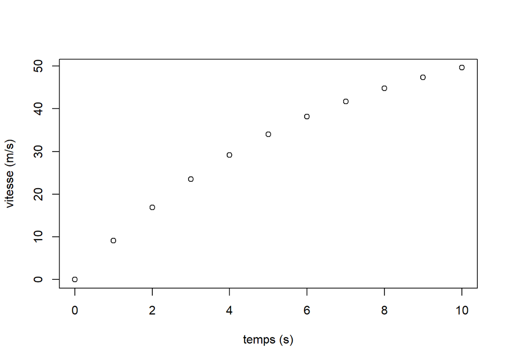

```r
# test
out = freefallin_fun(g = 9.81, m = 80, c = 12.5, t = 0:10)
plot(x = 0:10, y = out, xlab = "temps (s)", ylab = "vitesse (m/s)")
```

#### Simuler le comportement du modèle

Nous pouvons maintenant interroger le modèle pour comprendre comment la masse du parachutiste influence sa vitesse en chute libre. Pour cela, nous allons définir une série de masse corporelle à stocker dans un vecteur et appliquer notre fonction sur chaque élément du vecteur à l’aide de la fonction `lapply()`

```r
# Importer la fonction
source(here("R/funs/freefallin_fun.R"))

# Définir les paramètres
g = 9.81
c = 12.5
t = 0:10

# Parachutiste de 40 à 120 kg
m_range = c(40:120)

# appliquer la fonction pour chaque valeur de paramètre
# Stocker chaque vélocité dans liste
out = lapply(m_range, freefallin_fun, g = g, c = c, t = t)
out[1:2] # Afficher les 2 premiers éléments de la liste
```

```
[[1]]
 [1]  0.000000  8.425122 14.589073 19.098716 22.398041 24.811879 26.577881
 [8] 27.869915 28.815188 29.506764 30.012732

[[2]]
 [1]  0.000000  8.455636 14.689243 19.284741 22.672603 25.170180 27.011427
 [8] 28.368818 29.369505 30.107225 30.651082
```

Nous pouvons ensuite stocker ces informations sous forme de `dataframe` pour les représenter plus facilement à l’aide de `ggplot`

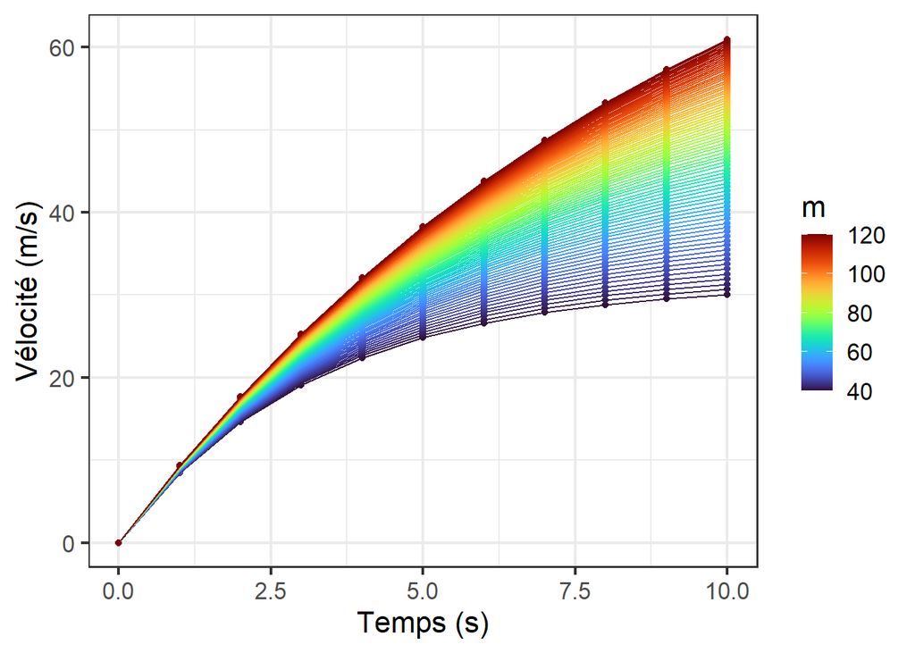

```r
df = data.frame(
  m = rep(m_range, each = length(t)), # valeur de masse répétée à chaque pas de temps
  t = rep(t, length(m_range)), # temps répétée pour chaque masse
  v = unlist(out) # vélositées mises bout à bout
  )

df %>%
  ggplot(aes(x = t, y = v, group = m, color = m)) +
  geom_point() +
  geom_line() +
  scale_color_viridis(option = "H") +
  xlab("Temps (s)") +
  ylab("Vélocité (m/s)") +
  theme_bw(16)
```

### Tutoriel 2: Simulations d’un modèle QSAR

Nous avons également vu comment simuler la relation entre toxicité et lipophilie des contaminants à l’aide d’un modèle QSAR de la forme:

$$\begin{aligned}
toxicité &= 1 / LC_{50} \\
log(K_{ow}) &\sim N(\mu_{Kow}, \sigma_{Kow}) \\
toxicité &\sim N(\mu_{toxicité}, \sigma_{toxicité}) \\
\mu_{toxicité} &= \beta_0 + \beta_1 log(K_{ow}) \\
\end{aligned}$$

#### Stockage des paramètres

```r
n_compo = 100 # nombre de composés
b0 = -4 # Ordonnée à l'origine
b1 = .9 # Pente
sigma = .25 # variance résiduelle
```

D’après la figure 1 de Könemann 1981, le coefficient de partage des molécules considérées (log(Kow)) peut être approximé par une loi normale de moyenne 2 et un écart type de 1. Avec la fonction `rnorm()`, nous pouvons simuler 100 molécules selon cette loi.

```r
logKow = rnorm(n_compo, 2, 1)  # vecteur de Kow
```

Pour simuler l’effet de log(Kow) sur la valeure de toxicité, il suffit d’appliquer la fonction `rnorm()` à nouveau, cette fois sur le vecteur de valeures de log(Kow) et en appliquant la formule linéaire reliant la toxicité à Kow:

```r
log_inv_LC50 = rnorm(n_compo, b0 + b1 * logKow, sigma)
```

Stockons ces données dans un dataframe pour pouvoir les représenter graphiquement

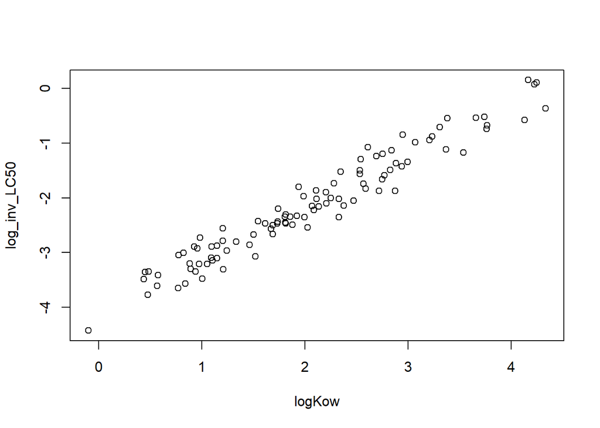

```r
df = data.frame( # stockage
  logKow = logKow,
  log_inv_LC50 = log_inv_LC50
)

plot(log_inv_LC50 ~ logKow, df)
```

### Exporter les tutoriels sous forme de page web

Maintenant que nous avons fini d’exposer nos simulations et leurs résulats, nous pouvons facilement exporter notre document quarto au format voulu, ici une page html. Pour ce faire, le plus simple est d’utiliser la suite d’incantations suivante directement depuis le terminal:

- `quarto render` pour (re)compiler votre rapport
- `git add .` pour ajouter les changements produits
- `git commit -m "votre message ici"` pour documenter vos changements
- `git push` pour pousser vers votre branche principale sur github

Utilisez les instructions [ici](https://quarto.org/docs/publishing/github-pages.html) pour finaliser l’affichage de la page sur github.

**Attention!**

Deux choses importantes à prendre en compte pour une compilation sans douleur:

- Bien vérifier que le fichier `_quarto.yml` affiche l’option `output-dir: docs` pour que les rapport s’exporte directement dans le fichier `docs`. Ceci est déjà préparamétré si vous utilisez le template [rroyaute/gh-template-rr](https://github.com/rroyaute/gh-template-rr/tree/main).
- Utilisez le package `{here}` pour facilement pointer vers les fichiers à importer en dehors du dossier `\quarto`. Exemple: écrire `source(here("R/funs/freefallin_fun.R"))` plutôt que `source("R/funs/freefallin_fun.R")`